# edav-final

```r
library(tidyverse)
library(dplyr)
library(ggplot2)
library(forcats)
library(Hmisc)
library(HH)
library(mi)
# devtools::install_github('CRAN/extracat')
library(extracat)
```

```r
# load data
moma_artists <- read_csv("./data/raw/moma/Artists.csv")
moma_artworks <- read_csv("./data/raw/moma/Artworks.csv")
met <- read_csv("./data/raw/met/MetObjects.csv")
tate_artist <- read_csv("./data/raw/tate/artist_data.csv")
tate_artwork <- read_csv("./data/raw/tate/artwork_data.csv")
# set color
mycolor <- "#80593D"
myfill <- "#9FC29F"

# 1. we start with MOMA
# after a closer look at the dataset,
# we realized that some columns are redundants;
# thus, we do some clean up and get the columns we need.
# specifically, artist name, nationality, gender, beginDate, endDate
moma_artists <- moma_artists[c(2,4,5,6,7)]

# check column, row number
dim(moma_artists)
```

```
## [1] 15853     5
```

Thus, we are dealing with a dataset that has 5 columns and 15,853 rows.

```r
# 1.1 Check NAs
# for completeness of this project, let's check the NAs
colSums(is.na(moma_artists))
```

```
## DisplayName Nationality      Gender   BeginDate     EndDate
##           0        2556        3179           0           0
```

This is weird, because it is impossible for BeginDate and EndDate columns to not have NAs, as they contain so many rows with 0s. Thus, we need to convert 0 to NAs.

```r
# replace all zeros to NA for BeginDate and EndDate
moma_artists$BeginDate[(moma_artists$BeginDate == 0)] <- NA
moma_artists$EndDate[(moma_artists$EndDate == 0)] <- NA

# check again
colSums(is.na(moma_artists))
```

```
## DisplayName Nationality      Gender   BeginDate     EndDate
##           0        2556        3179        3791       10779
```

Now it is returning the correct value, and it is obvious from the report that we are less able to get the death years for many artists. In fact, 10779/15853 ~ 68% of the artists in the dataset. At this point, we are not planning to focus on analyzing the NAs, but this gives good contextual knowledge later when we are exploring the dataset and the natural limitation that this dataset imposed on us.

```r
# since Nationality has fewer NA numbers, see if we can find out any pattern frm the NAs
# we try to see NAs based on Nationality: is there a nationality that has a lot of NAs?
moma_na_by <- moma_artists %>% group_by(Nationality, BeginDate) %>% dplyr::summarise(Total = n()) %>% arrange(Total)

# from the process, we realized that in this dataset, there is a row that indicated "Nationality unknown" that we should convert to NA type.
moma_artists$Nationality[moma_artists$Nationality == "Nationality unknown"] <- NA

# run again
colSums(is.na(moma_artists))
```

```
## DisplayName Nationality      Gender   BeginDate     EndDate
##           0        2736        3179        3791       10779
```

Uncovered 180 NA Nationalities.

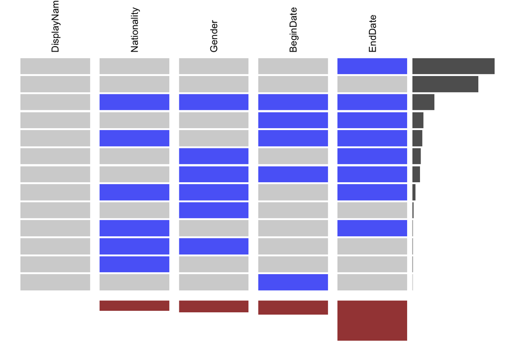

```r
visna(moma_artists, sort = 'r')
```

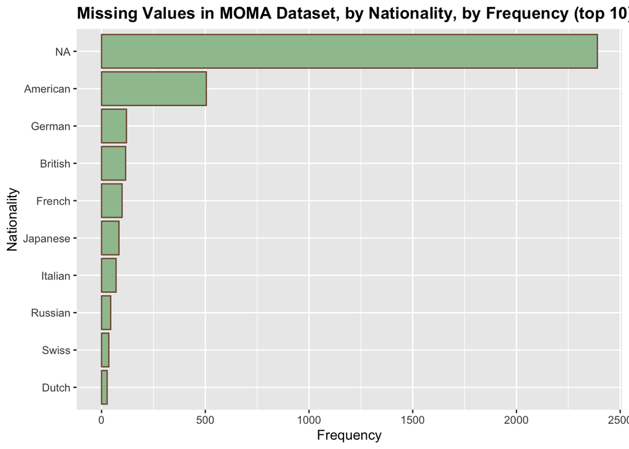

```r
# plot again
moma_na_by <- moma_artists %>% group_by(Nationality, BeginDate) %>% dplyr::summarise(Total = n()) %>% arrange(Total)

# only keep those with NA BeginDate
moma_na_by <- moma_na_by %>% group_by(BeginDate) %>% filter(is.na(BeginDate))

# plot on top 10 by frequency
ggplot(tail(moma_na_by, 10), aes(fct_reorder(Nationality, Total), Total)) +
  geom_bar(stat = "identity") +
  ggtitle("Missing Values in MOMA Dataset, by Nationality, by Frequency (top 10)") +
  xlab("Nationality") +
  ylab("Frequency") +
  geom_col(color = mycolor, fill = myfill) +
  coord_flip() +
  theme(plot.title = element_text(face = "bold"))
```

It seems that there are too many NA nationality with NA BeginDates; let’s exclude that row and replot

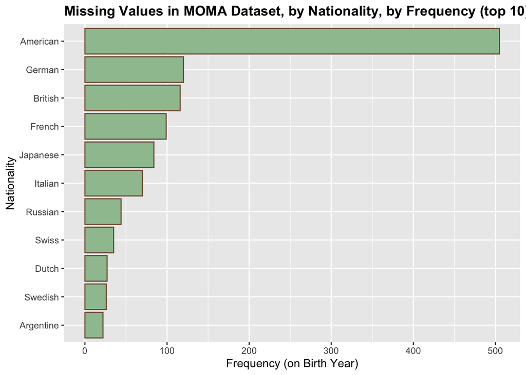

```r
# replot
ggplot(moma_na_by[(nrow(moma_na_by)-11):(nrow(moma_na_by)-1), ], aes(fct_reorder(Nationality, Total), Total)) +
  geom_bar(stat = "identity") +
  ggtitle("Missing Values in MOMA Dataset, by Nationality, by Frequency (top 10), w/o NAs") +
  xlab("Nationality") +
  ylab("Frequency (on Birth Year)") +
  geom_col(color = mycolor, fill = myfill) +
  coord_flip() +
  theme(plot.title = element_text(face = "bold"))
```

So it appears that MOMA has a lot of missing values of birth year from American artists.

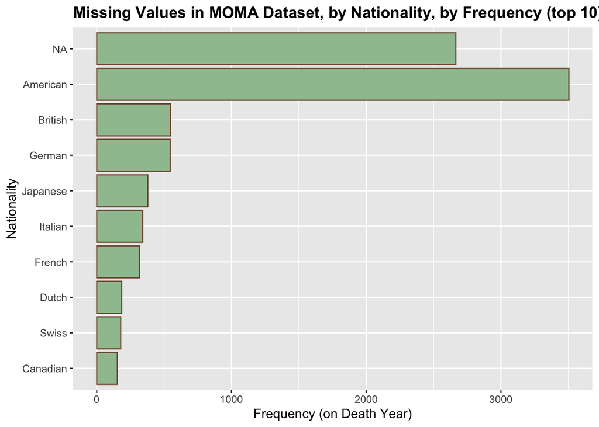

```r
# only keep those with NA EndDate
moma_na_dy <- moma_artists %>% group_by(Nationality, EndDate) %>% dplyr::summarise(Total = n()) %>% arrange(Total)

moma_na_dy <- moma_na_dy %>% group_by(EndDate) %>% filter(is.na(EndDate))

# plot on top 10 by frequency
ggplot(tail(moma_na_dy, 10), aes(fct_reorder(Nationality, Total), Total)) +
  geom_bar(stat = "identity") +
  ggtitle("Missing Values in MOMA Dataset, by Nationality, by Frequency (top 10)") +
  xlab("Nationality") +
  ylab("Frequency (on Death Year)") +
  geom_col(color = mycolor, fill = myfill) +
  coord_flip() +
  theme(plot.title = element_text(face = "bold"))
```

Surprisingly, this time, there are more missing values with American artists in terms their death years than NA nationality artists.

We now have gathered some thoughts and intuitions about the missing values in this dataset; we now turned to some initial exploratories.

```r
# 1.2 Count by Nationality
# One of the first questions that we asked ourselves was the following: From what nationality, MOMA collected the most artworks? That said, we will plot a nationality-frequency plot.
# We first extract what we need
moma_artists_origin <- moma_artists[2] %>% group_by(Nationality) %>% dplyr::summarize(Frequency=n()) %>% arrange(Frequency)

# check the stats summary of this dataset
describe(moma_artists_origin)
```

```
## moma_artists_origin
##
##  2  Variables      127  Observations
## ---------------------------------------------------------------------------
## Nationality
##        n  missing distinct
##      126        1      126
##
## lowest : Afghan     Albanian   Algerian   American   Argentine
## highest: Venezuelan Vietnamese Welsh      Yugoslav   Zimbabwean
## ---------------------------------------------------------------------------
## Frequency
##        n  missing distinct     Info     Mean      Gmd      .05      .10
##      127        0       53    0.986    124.8    225.3      1.0      1.0
##      .25      .50      .75      .90      .95
##      2.0      6.0     44.0    165.0    446.2
##
## lowest :    1    2    3    4    5, highest:  872  880  977 2736 5472
## ---------------------------------------------------------------------------
```

From this stats report, we are expecting to see a long tail effect from this dataset; thus, we first take the top 5% and observe any pattern. Top 5% is any Nationality with frequency greater than 446.2

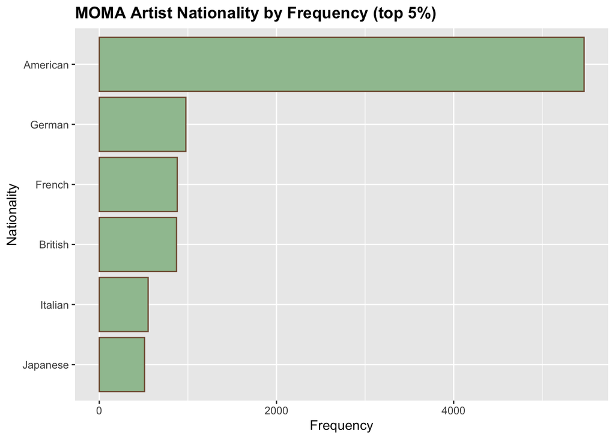

```r
moma_artists_org5 <- moma_artists_origin %>% group_by (Frequency) %>% filter(Frequency > 446)

# filter out na for now
moma_artists_org5 <- moma_artists_org5 %>% group_by(Nationality) %>% filter(is.na(Nationality) == FALSE)

# frequency of nationality
ggplot(moma_artists_org5, aes(fct_reorder(Nationality, Frequency), Frequency)) +
  geom_bar(stat = "identity") +
  ggtitle("MOMA Artist Nationality by Frequency (top 5%)") +
  xlab("Nationality") +
  geom_col(color = mycolor, fill = myfill) +
  coord_flip() +
  theme(plot.title = element_text(face = "bold"))
```

We observed that the number of American artists is nearly 5 times the number of artists from other countries.

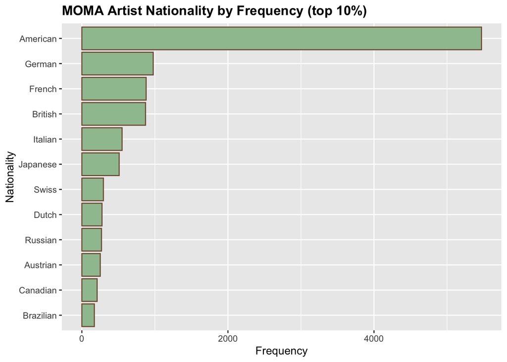

```r
# if by top 10%, which is 165
moma_artists_org10 <- moma_artists_origin %>% group_by (Frequency) %>% filter(Frequency > 165)

# filter out NA for now
moma_artists_org10 <- moma_artists_org10 %>% group_by (Nationality) %>% filter(is.na(Nationality)== FALSE)


# frequency of nationality
ggplot(moma_artists_org10, aes(fct_reorder(Nationality, Frequency), Frequency)) +
  geom_bar(stat = "identity") +
  ggtitle("MOMA Artist Nationality by Frequency (top 10%)") +
  xlab("Nationality") +
  geom_col(color = mycolor, fill = myfill) +
  coord_flip() +
  theme(plot.title = element_text(face = "bold"))
```

Thus, we observed that among the 90% of the artworks collected by MOMA (which are 12 countries), 8 are European countries, 2 are North American countries, 1 is South American and 1 is Asian.

```r
# Let's do something fun. Let's create a spatial map.
# since so, we wont care about NAs
moma_artists_org10$region <- moma_artists_org10$Nationality
moma_artists_org10$value <- moma_artists_org10$Frequency

# hardcode each nationality to country based on *admin1.regions*
moma_artists_org10$region[moma_artists_org10$region == 'American'] <- 'united states of america'
moma_artists_org10$region[moma_artists_org10$region == 'German'] <- 'germany'
moma_artists_org10$region[moma_artists_org10$region == 'French'] <- 'france'
moma_artists_org10$region[moma_artists_org10$region == 'British'] <- 'united kingdom'
moma_artists_org10$region[moma_artists_org10$region == 'Italian'] <- 'italy'
moma_artists_org10$region[moma_artists_org10$region == 'Japanese'] <- 'japan'
moma_artists_org10$region[moma_artists_org10$region == 'Swiss'] <- 'switzerland'
moma_artists_org10$region[moma_artists_org10$region == 'Dutch'] <- 'netherlands'
moma_artists_org10$region[moma_artists_org10$region == 'Russian'] <- 'russia'
moma_artists_org10$region[moma_artists_org10$region == 'Austrian'] <- 'austria'
moma_artists_org10$region[moma_artists_org10$region == 'Canadian'] <- 'canada'
moma_artists_org10$region[moma_artists_org10$region == 'Brazilian'] <- 'brazil'

# plot
# moma_artists_org10(admin1.map)
```

```r
# 1.3 Count by Birth Year
moma_artists_by <- moma_artists[4] %>% group_by (BeginDate) %>% dplyr::summarize(Frequency=n()) %>% arrange(Frequency)
moma_artists_by$BeginDate <- as.character(moma_artists_by$BeginDate)

# again, check the stats
describe(moma_artists_by)
```

```
## moma_artists_by
##
##  2  Variables      234  Observations
## ---------------------------------------------------------------------------
## BeginDate
##        n  missing distinct
##      233        1      233
##
## lowest : 1730 1731 1746 1753 1765, highest: 2012 2014 2015 2016 2017
## ---------------------------------------------------------------------------
## Frequency
##        n  missing distinct     Info     Mean      Gmd      .05      .10
##      234        0      105    0.999    67.75    90.84     1.00     2.00
##      .25      .50      .75      .90      .95
##     6.00    22.50    94.25   138.40   153.00
##
## lowest :    1    2    3    4    5, highest:  177  184  193  198 3791
##
## Value          0    50   100   150   200  3800
## Frequency    121    33    42    33     4     1
## Proportion 0.517 0.141 0.179 0.141 0.017 0.004
##
## For the frequency table, variable is rounded to the nearest 50
## ---------------------------------------------------------------------------
```

Again, we take the 95% percentile, which is any Nationality having more than 153 counts.

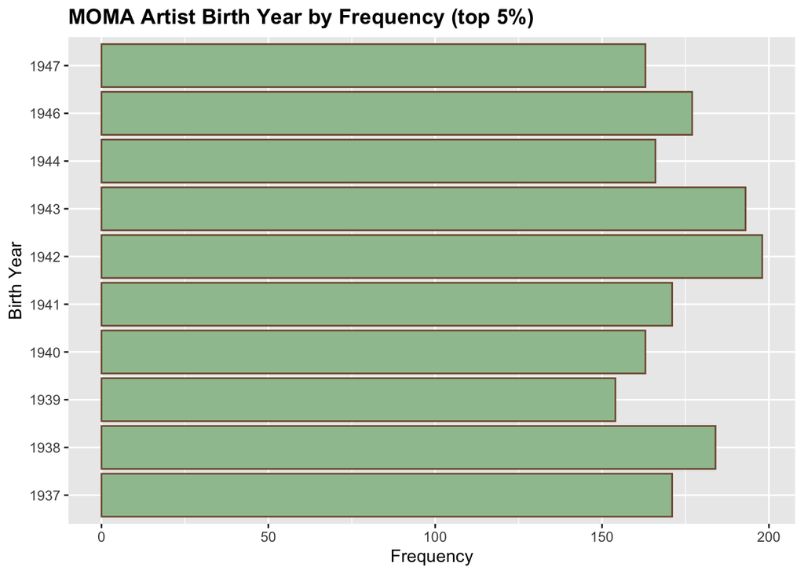

```r
# let's see the top 5%
moma_artists_by5 <- moma_artists_by %>% group_by(Frequency) %>% filter(Frequency > 153)

# and exclude NA for now
moma_artists_by5 <- moma_artists_by5 %>% group_by(BeginDate) %>% filter(is.na(BeginDate) == FALSE)

# frequency of birth year
ggplot(moma_artists_by5, aes(BeginDate, Frequency)) +
  geom_bar(stat = "identity") +
  ggtitle("MOMA Artist Birth Year by Frequency (top 5%)") +
  xlab("Birth Year") +
  geom_col(color = mycolor, fill = myfill) +
  coord_flip() +
  theme(plot.title = element_text(face = "bold"))
```

We observed that these ten consequentive years (excluding 1945, and very surprisingly!) accounts for the birth year of the artists that are most recognized by MOMA. Perhaps, these ten years really made artists creative :)

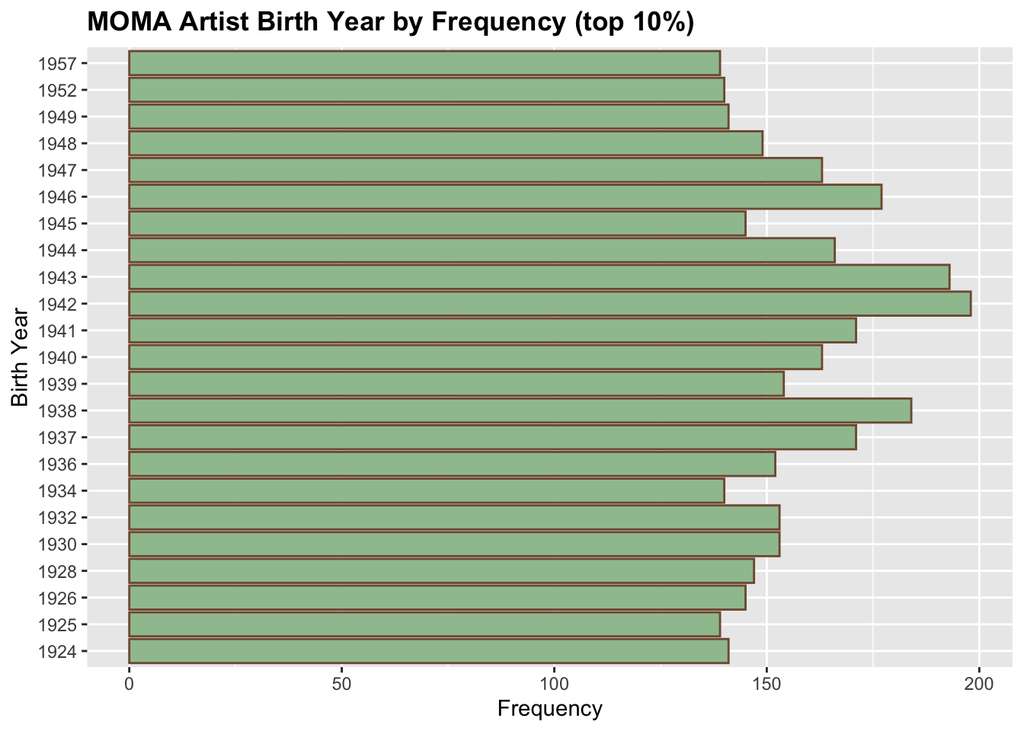

```r
# let's see the top 10%, which is greater than 138
moma_artists_by10 <- moma_artists_by %>% group_by(Frequency) %>% filter(Frequency > 138)

# and exclude NA for now
moma_artists_by10 <- moma_artists_by10 %>% group_by(BeginDate) %>% filter(is.na(BeginDate) == FALSE)

# frequency of birth year
ggplot(moma_artists_by10, aes(BeginDate, Frequency)) +
  geom_bar(stat = "identity") +
  ggtitle("MOMA Artist Birth Year by Frequency (top 10%)") +
  xlab("Birth Year") +
  geom_col(color = mycolor, fill = myfill) +
  coord_flip() +
  theme(plot.title = element_text(face = "bold"))
```

Thus, we can narrow down our focus to this span of 40 years: 1920 - 1960. But we will particularly examine the “prime” years: 1937 - 1947.

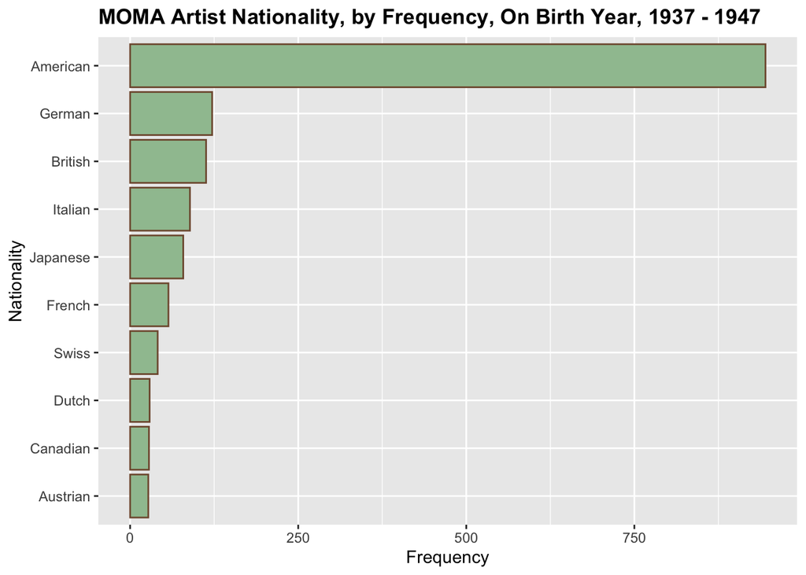

```r
# 1.4 Subsample years: 1937 - 1947
moma_artists_sub <- moma_artists %>% group_by(BeginDate) %>% filter(BeginDate >= 1937 & BeginDate <= 1947)

# 1.4.1 On Nationality
# first, a high level pic
moma_artists_sub_org <- moma_artists_sub %>% group_by(Nationality) %>% dplyr::summarize(Frequency = n()) %>% arrange(Frequency)

# NA only takes a small proportion, so we exclude it
moma_artists_sub_org <- moma_artists_sub_org %>% group_by(Nationality) %>% filter(is.na(Nationality) == FALSE)

# facet on each year
ggplot(tail(moma_artists_sub_org,10), aes(fct_reorder(Nationality, Frequency), Frequency)) +
  geom_bar(stat = "identity") +
  ggtitle("MOMA Artist Nationality, by Frequency, On Birth Year, 1937 - 1947") +
  xlab("Nationality") +
  geom_col(color = mycolor, fill = myfill) +
  coord_flip() +
  theme(plot.title = element_text(face = "bold"))
```

They collected a lot from American artists. But who are they? Can we tell?

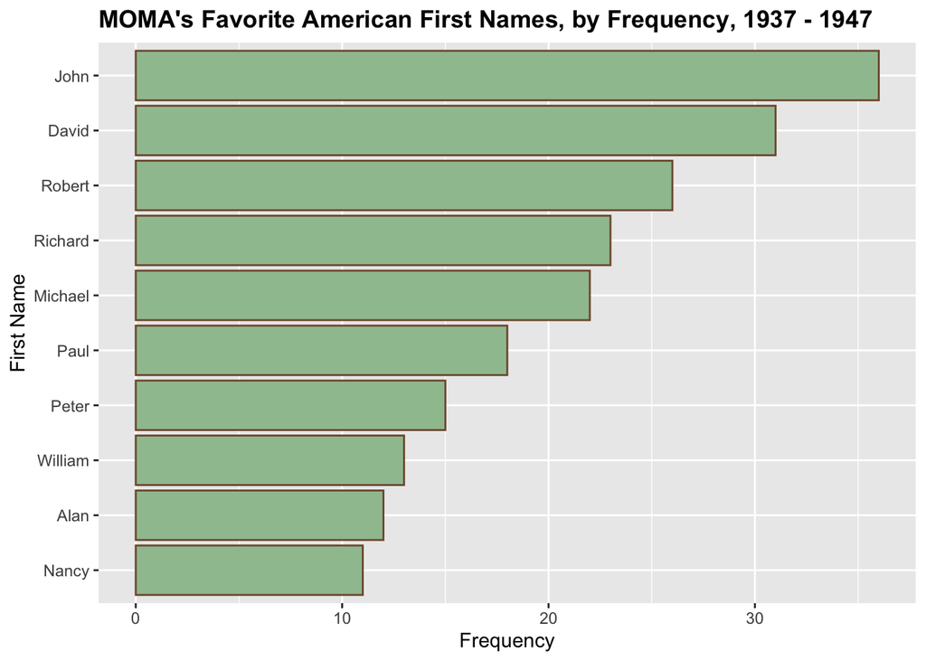

```r
moma_artists_sub_us <- moma_artists_sub %>% group_by(Nationality) %>% filter(Nationality == 'American')

first_name_us <- as.data.frame(word(moma_artists_sub_us$DisplayName,1))
colnames(first_name_us) <- 'first_name'

first_name_count <- first_name_us %>% group_by(first_name) %>% dplyr::summarise(Frequency = n()) %>% arrange(Frequency)

# first name frequency
ggplot(tail(first_name_count,10), aes(fct_reorder(first_name, Frequency), Frequency)) +
  geom_bar(stat = "identity") +
  ggtitle("MOMA's Favorite American First Names, by Frequency, 1937 - 1947") +
  xlab("First Name") +
  geom_col(color = mycolor, fill = myfill) +
  coord_flip() +
  theme(plot.title = element_text(face = "bold"))
```

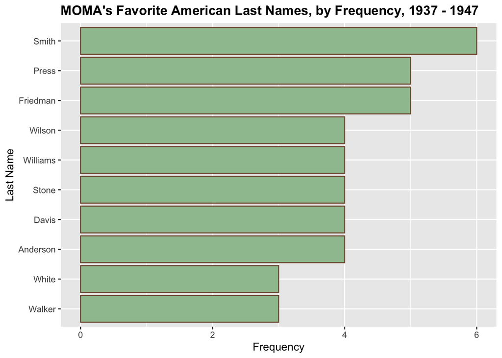

```r
# let's check last name
last_name_us <- as.data.frame(word(moma_artists_sub_us$DisplayName,-1))
colnames(last_name_us) <- 'last_name'

last_name_count <- last_name_us %>% group_by(last_name) %>% dplyr::summarise(Frequency = n()) %>% arrange(Frequency)

# first name frequency
ggplot(tail(last_name_count,10), aes(fct_reorder(last_name, Frequency), Frequency)) +
  geom_bar(stat = "identity") +
  ggtitle("MOMA's Favorite American Last Names, by Frequency, 1937 - 1947") +
  xlab("Last Name") +
  geom_col(color = mycolor, fill = myfill) +
  coord_flip() +
  theme(plot.title = element_text(face = "bold"))
```

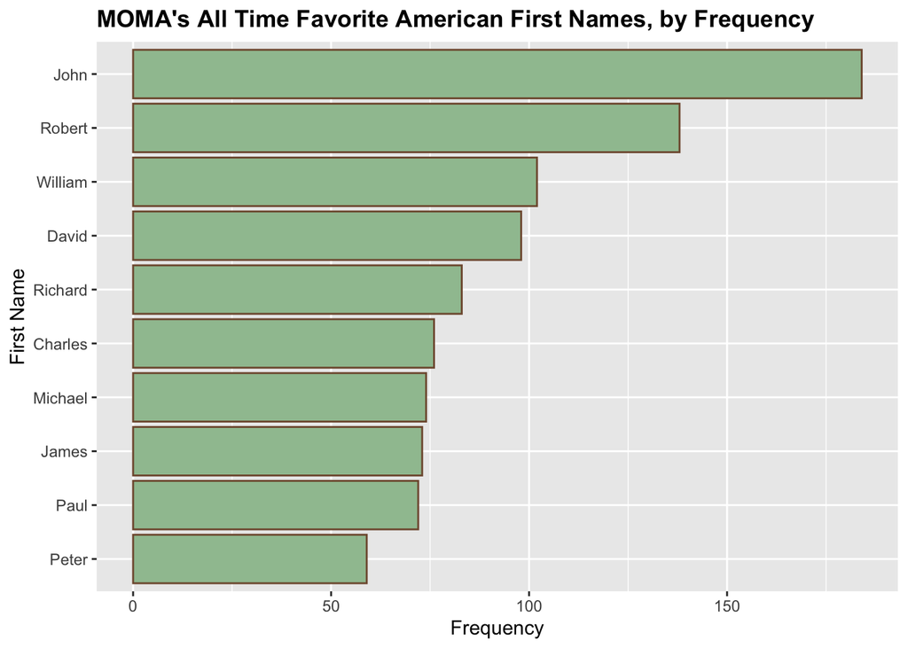

```r
# if all
all_us <- moma_artists %>% group_by(Nationality) %>% filter(Nationality == 'American')
first_name_all <- as.data.frame(word(all_us$DisplayName,1))
colnames(first_name_all) <- 'first_name'

first_name_allc <- first_name_all %>% group_by(first_name) %>% dplyr::summarise(Frequency = n()) %>% arrange(Frequency)

# first name frequency
ggplot(tail(first_name_allc,10), aes(fct_reorder(first_name, Frequency), Frequency)) +
  geom_bar(stat = "identity") +
  ggtitle("MOMA's All Time Favorite American First Names, by Frequency") +
  xlab("First Name") +
  geom_col(color = mycolor, fill = myfill) +
  coord_flip() +
  theme(plot.title = element_text(face = "bold"))
```

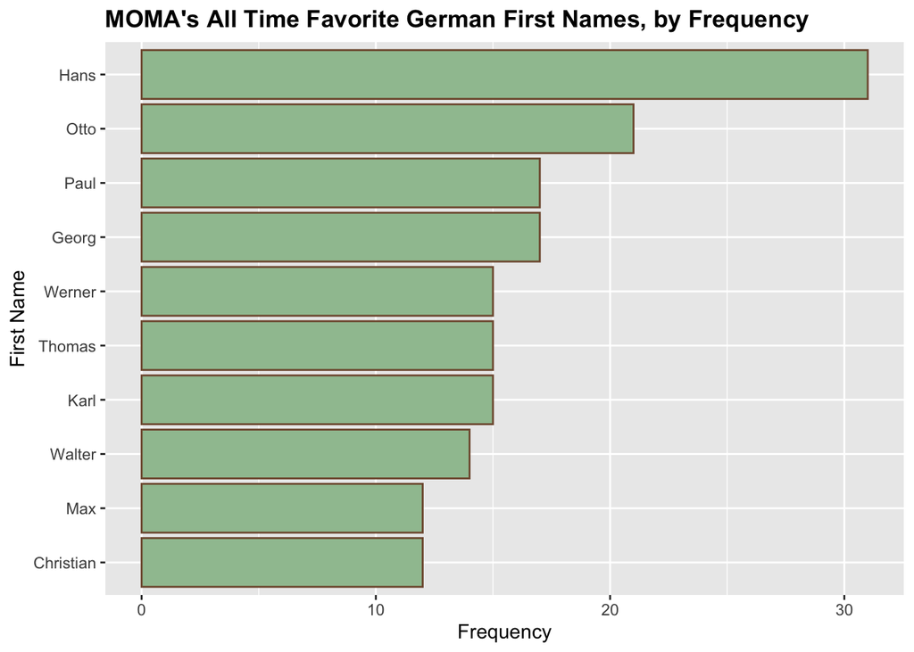

```r
# if all
all_de <- moma_artists %>% group_by(Nationality) %>% filter(Nationality == 'German')
first_name_all_de <- as.data.frame(word(all_de$DisplayName,1))
colnames(first_name_all_de) <- 'first_name'

first_name_allc_de <- first_name_all_de %>% group_by(first_name) %>% dplyr::summarise(Frequency = n()) %>% arrange(Frequency)

# first name frequency
ggplot(tail(first_name_allc_de,10), aes(fct_reorder(first_name, Frequency), Frequency)) +
  geom_bar(stat = "identity") +
  ggtitle("MOMA's All Time Favorite German First Names, by Frequency") +
  xlab("First Name") +
  geom_col(color = mycolor, fill = myfill) +
  coord_flip() +
  theme(plot.title = element_text(face = "bold"))
```

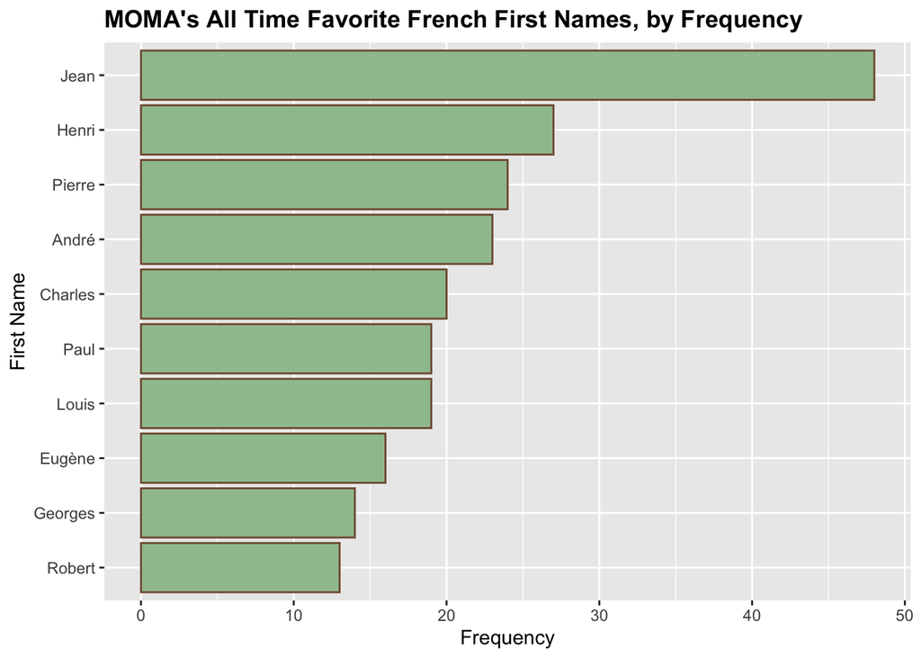

```r
# if all
all_fr <- moma_artists %>% group_by(Nationality) %>% filter(Nationality == 'French')
first_name_all_fr <- as.data.frame(word(all_fr$DisplayName,1))
colnames(first_name_all_fr) <- 'first_name'

first_name_allc_fr <- first_name_all_fr %>% group_by(first_name) %>% dplyr::summarise(Frequency = n()) %>% arrange(Frequency)

# first name frequency
ggplot(tail(first_name_allc_fr,10), aes(fct_reorder(first_name, Frequency), Frequency)) +
  geom_bar(stat = "identity") +
  ggtitle("MOMA's All Time Favorite French First Names, by Frequency") +
  xlab("First Name") +
  geom_col(color = mycolor, fill = myfill) +
  coord_flip() +
  theme(plot.title = element_text(face = "bold"))
```

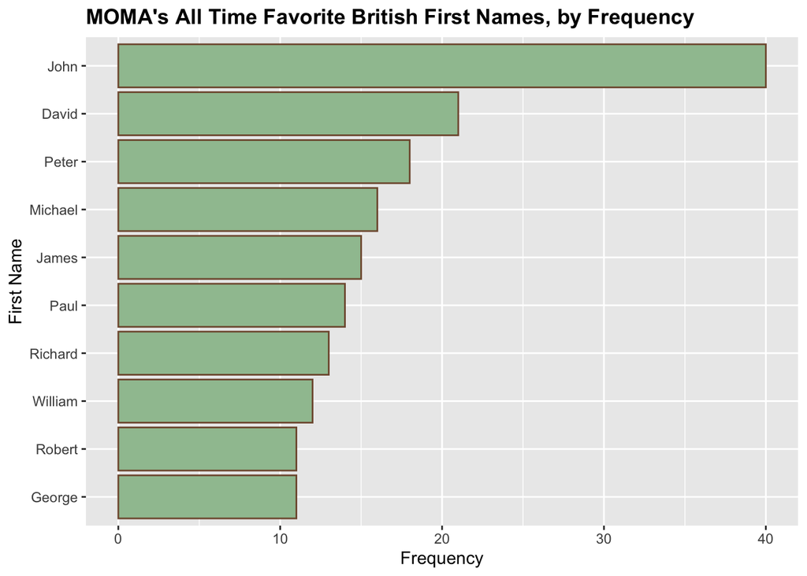

```r
# if all
all_uk <- moma_artists %>% group_by(Nationality) %>% filter(Nationality == 'British')
first_name_all_uk <- as.data.frame(word(all_uk$DisplayName,1))
colnames(first_name_all_uk) <- 'first_name'

first_name_allc_uk <- first_name_all_uk %>% group_by(first_name) %>% dplyr::summarise(Frequency = n()) %>% arrange(Frequency)

# first name frequency
ggplot(tail(first_name_allc_uk,10), aes(fct_reorder(first_name, Frequency), Frequency)) +
  geom_bar(stat = "identity") +
  ggtitle("MOMA's All Time Favorite British First Names, by Frequency") +
  xlab("First Name") +
  geom_col(color = mycolor, fill = myfill) +
  coord_flip() +
  theme(plot.title = element_text(face = "bold"))
```

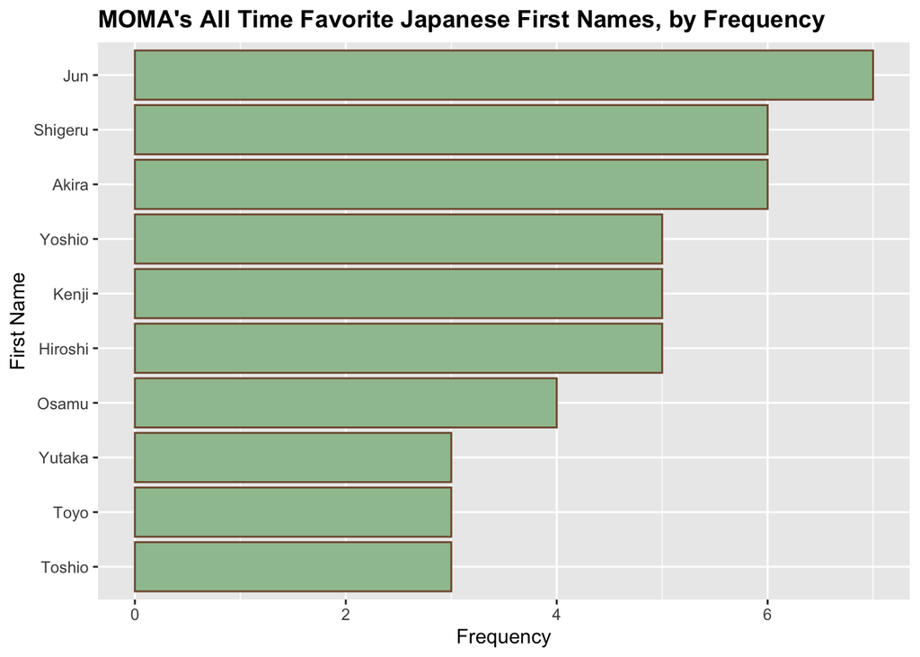

```r
# if all
all_jp <- moma_artists %>% group_by(Nationality) %>% filter(Nationality == 'Japanese')
first_name_all_jp <- as.data.frame(word(all_jp$DisplayName,1))
colnames(first_name_all_jp) <- 'first_name'

first_name_allc_jp <- first_name_all_jp %>% group_by(first_name) %>% dplyr::summarise(Frequency = n()) %>% arrange(Frequency)

# first name frequency
ggplot(tail(first_name_allc_jp,10), aes(fct_reorder(first_name, Frequency), Frequency)) +
  geom_bar(stat = "identity") +
  ggtitle("MOMA's All Time Favorite Japanese First Names, by Frequency") +
  xlab("First Name") +
  geom_col(color = mycolor, fill = myfill) +
  coord_flip() +
  theme(plot.title = element_text(face = "bold"))
```

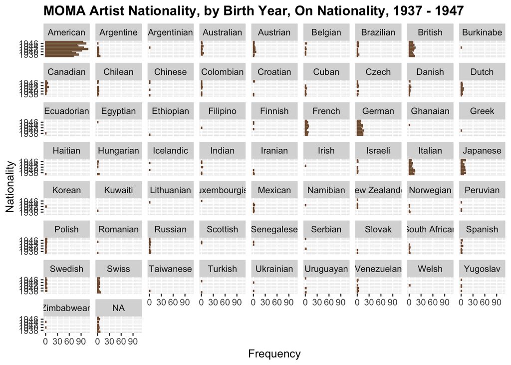

```r
# little messy, try reverse
moma_artists_sub_by <- moma_artists_sub %>% group_by(Nationality, BeginDate) %>% dplyr::summarize(Frequency = n()) %>% arrange(Frequency)

# facet on each year
ggplot(moma_artists_sub_by, aes(BeginDate, Frequency)) +
  geom_bar(stat = "identity") +
  ggtitle("MOMA Artist Nationality, by Birth Year, On Nationality, 1937 - 1947") +
  xlab("Nationality") +
  geom_col(color = mycolor, fill = myfill) +
  coord_flip() +
  facet_wrap(~Nationality) +
  theme(plot.title = element_text(face = "bold"))
```

```r
# Now, let's check by gender of those top 5%
moma_artists$Gender <- tolower(moma_artists$Gender)
moma_artists_gender <- moma_artists %>% group_by(Gender, Nationality) %>% dplyr::summarize(Frequency=n()) %>% arrange(Frequency) %>% filter(Nationality %in% c("American", "British", "German", "Italian", "Japanese"))
```

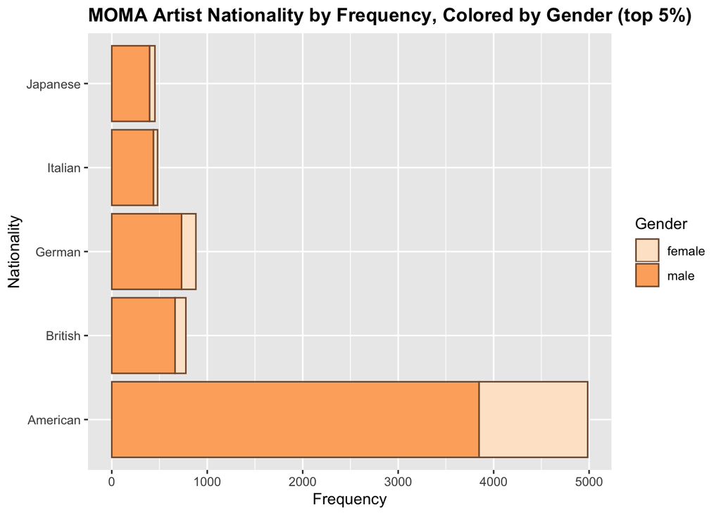

```r
#if exclude NA for now
moma_artists_gender_nona <- moma_artists_gender %>% group_by(Gender) %>% filter(Gender %in% c("female", "male"))
ggplot(moma_artists_gender_nona, aes(Nationality, Frequency, fill = Gender)) +
  geom_bar(stat = "identity") +
  ggtitle("MOMA Artist Nationality by Frequency, Colored by Gender (top 5%)") +
  xlab("Nationality") +
  scale_fill_brewer(palette= "Oranges")+
  geom_col(color = mycolor) +
  coord_flip() +
  theme(plot.title = element_text(face = "bold"))
```

```r
# similarily, for birth year
moma_artists_birth_year_gender <- moma_artists %>% group_by(Gender, BeginDate) %>% dplyr::summarize(Frequency=n())

# just check the top 5%
moma_artists_birth_year_gender$BeginDate <- factor(moma_artists_birth_year_gender$BeginDate, levels = moma_artists_by5$BeginDate)

# take out NAs
moma_artists_birth_year_gender <- moma_artists_birth_year_gender %>% group_by(BeginDate) %>% filter( !is.na(BeginDate))
```

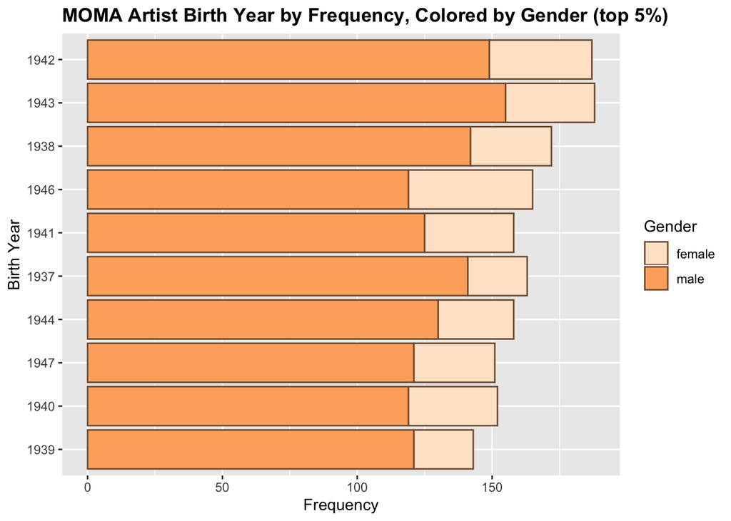

```r
moma_artists_birth_year_gender_nona <- moma_artists_birth_year_gender %>% group_by(Gender) %>% filter(Gender %in% c("female", "male"))

# plot it
ggplot(moma_artists_birth_year_gender_nona, aes(BeginDate, Frequency, fill = Gender)) +
  geom_bar(stat = "identity") +
  ggtitle("MOMA Artist Birth Year by Frequency, Colored by Gender (top 5%)") +
  xlab("Birth Year") +
  scale_fill_brewer(palette= "Oranges")+
  geom_col(color = mycolor) +
  coord_flip() +
  theme(plot.title = element_text(face = "bold"))
```

```r
# calculate male-female ratio and plot over time
```

[figure not shown]

```r
# diverging staked bar chart to better view the change on female frequency over time
likert(BeginDate~., moma_artists_birth_year_gender, positive.order = TRUE)
```

```r
# now let's take a look at the artworks
moma_artworks_class <- moma_artworks[14] %>%group_by(Classification) %>% dplyr::summarize(Frequency=n()) %>% arrange(Frequency)

# check stats
describe(moma_artworks_class)
```

```
## moma_artworks_class
##
##  2  Variables      31  Observations
## ---------------------------------------------------------------------------
## Classification
##        n  missing distinct
##       31        0       31
##
## lowest : (not assigned)      Architectural Model Architecture        Audio               Collage
## highest: Sculpture           Software            Textile             Video               Work on Paper
## ---------------------------------------------------------------------------
## Frequency
##        n  missing distinct     Info     Mean      Gmd      .05      .10
##       31        0       28    0.999     4456     7295      2.0      2.0
##      .25      .50      .75      .90      .95
##     19.5    789.0   2555.5  13815.0  29197.5
##
## lowest :     1     2     3     8    14, highest: 11923 13815 26845 31550 31880
##
## Value          0    50   400   550   700   800   850   900  1150  1700
## Frequency      9     3     1     1     1     1     2     1     1     1
## Proportion 0.290 0.097 0.032 0.032 0.032 0.032 0.065 0.032 0.032 0.032
##
## Value       2150  2350  2750  3350  3400 11900 13800 26850 31550 31900
## Frequency      1     1     1     1     1     1     1     1     1     1
## Proportion 0.032 0.032 0.032 0.032 0.032 0.032 0.032 0.032 0.032 0.032
##
## For the frequency table, variable is rounded to the nearest 50
## ---------------------------------------------------------------------------
```

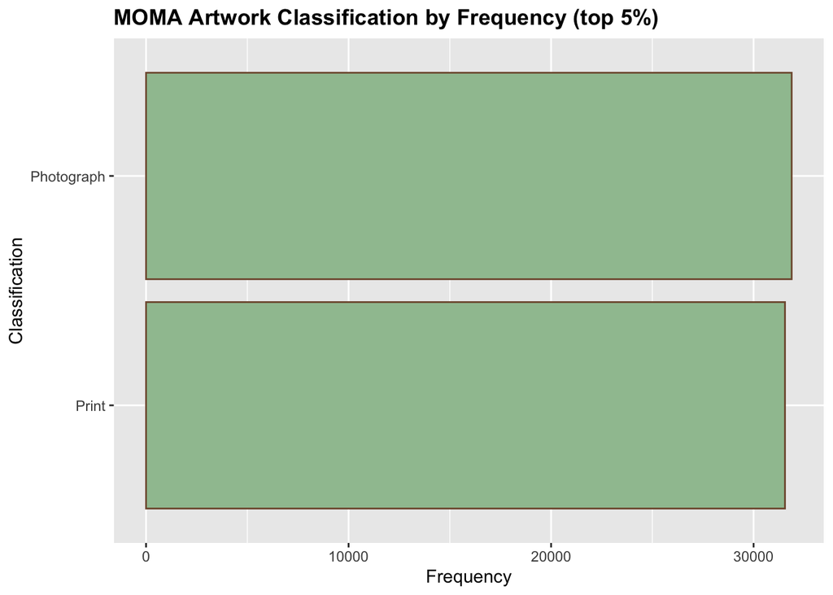

```r
# top 5% have more than 29197 frequency
moma_artworks_class_5per <- moma_artworks_class %>% group_by(Frequency) %>% filter(Frequency>29197)

# frequency of different classifications
ggplot(moma_artworks_class_5per, aes(fct_reorder(Classification, Frequency), Frequency)) +
  geom_bar(stat = "identity") +
  ggtitle("MOMA Artwork Classification by Frequency (top 5%)") +
  xlab("Classification") +
  geom_col(color = mycolor, fill = myfill) +
  coord_flip() +
  theme(plot.title = element_text(face = "bold"))
```

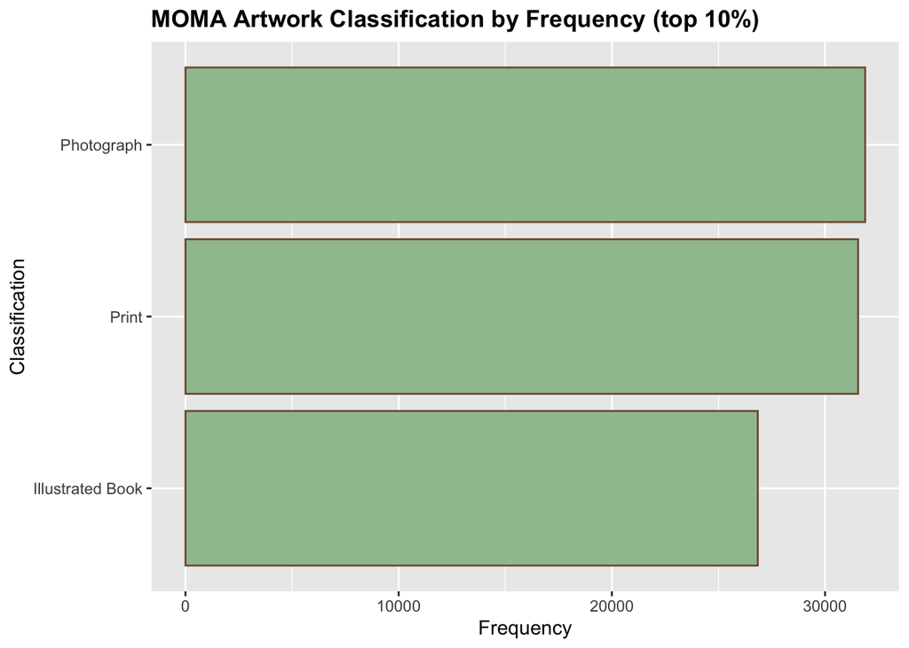

```r
# top 10%
moma_artworks_class_10per <- moma_artworks_class %>% group_by(Frequency) %>% filter(Frequency>13815)

ggplot(moma_artworks_class_10per, aes(fct_reorder(Classification, Frequency), Frequency)) +
  geom_bar(stat = "identity") +
  ggtitle("MOMA Artwork Classification by Frequency (top 10%)") +
  xlab("Classification") +
  geom_col(color = mycolor, fill = myfill) +
  coord_flip() +
  theme(plot.title = element_text(face = "bold"))
```

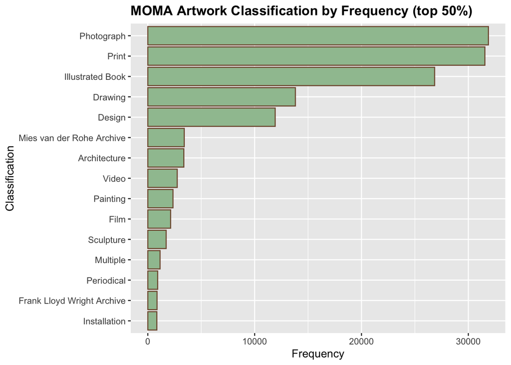

```r
# top 50%
moma_artworks_class_50per <- moma_artworks_class %>% group_by(Frequency) %>% filter(Frequency>789)

ggplot(moma_artworks_class_50per, aes(fct_reorder(Classification, Frequency), Frequency)) +
  geom_bar(stat = "identity") +
  ggtitle("MOMA Artwork Classification by Frequency (top 50%)") +
  xlab("Classification") +
  geom_col(color = mycolor, fill = myfill) +
  coord_flip() +
  theme(plot.title = element_text(face = "bold"))
```

```r
met_country <- met[32] %>% group_by(Country) %>% dplyr::summarize(Frequency=n()) %>% arrange(Frequency)

describe(met_country)
```

```
## met_country
##
##  2  Variables      929  Observations
## ---------------------------------------------------------------------------
## Country
##        n  missing distinct
##      928        1      928
##
## lowest : Afghanistan                      Afghanistan or Eastern Iran      Afghanistan or Iran              Afghanistan or Northeastern Iran Afghanistan or Turkmenistan
## highest: Zambia or Zimbabwe               Zambia?                          Zanzibar                         Zimbabwe                         Zimbabwe or Mozambique
## ---------------------------------------------------------------------------
## Frequency
##        n  missing distinct     Info     Mean      Gmd      .05      .10
##      929        0      100     0.87    506.1     1006      1.0      1.0
##      .25      .50      .75      .90      .95
##      1.0      1.0      5.0     28.0     95.2
##
## lowest :      1      2      3      4      5, highest:   3392   6121   8825  31080 395152
##
## Value           0   5000  10000  30000 395000
## Frequency     924      2      1      1      1
## Proportion  0.995  0.002  0.001  0.001  0.001
##
## For the frequency table, variable is rounded to the nearest 5000
## ---------------------------------------------------------------------------
```

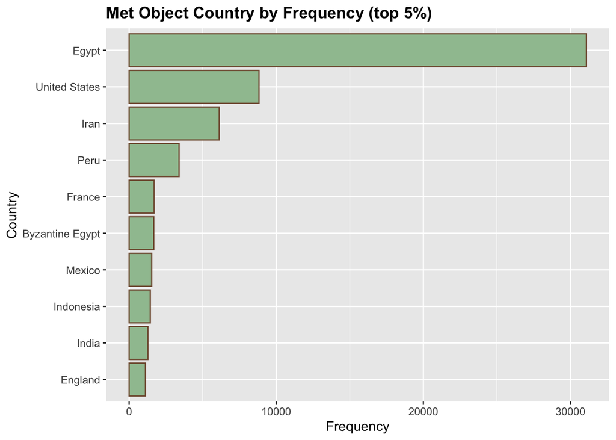

```r
met_country_top10 <- met_country %>% group_by(Frequency) %>% filter(Frequency >1000)

met_country_top10 <- met_country_top10[1:10,]

ggplot(met_country_top10, aes(fct_reorder(Country, Frequency), Frequency)) +
  geom_bar(stat = "identity") +
  ggtitle("Met Object Country by Frequency (top 5%)") +
  xlab("Country") +
  geom_col(color = mycolor, fill = myfill) +
  coord_flip() +
  theme(plot.title = element_text(face = "bold"))
```

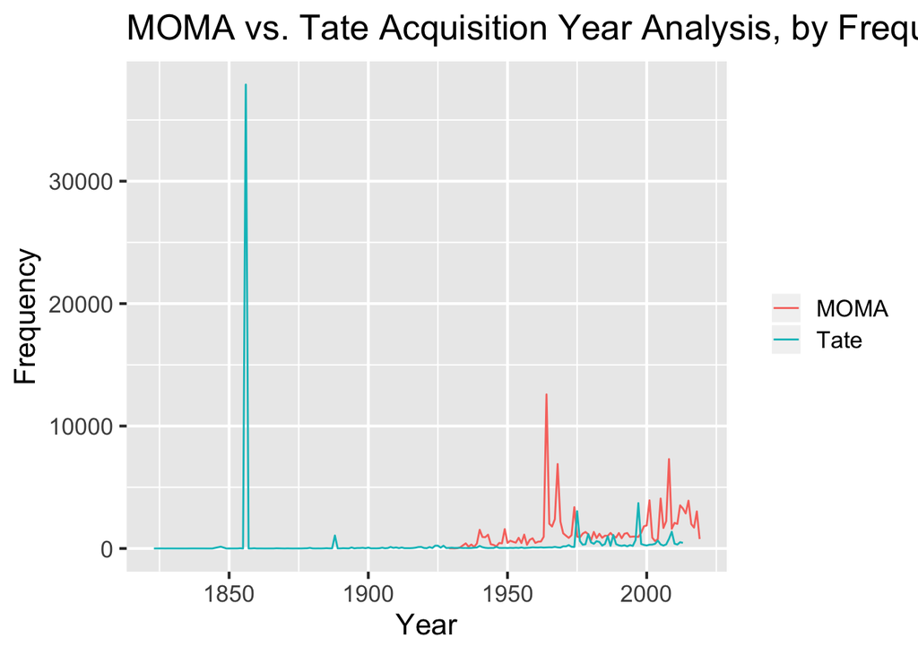

```r
# moma date acquired

# get artist, nationality, gender, medium, classification
moma_real <- moma_artworks[c(2,5,8,9,10,14,16)]

# get acquired year
test <- moma_real %>% mutate(Acq_year = substr(DateAcquired, 1,4))

# first, see time series
test <- test %>% group_by(Acq_year) %>% dplyr::summarise(Total= n()) %>% arrange(Total)
test$Acq_year <- strtoi(test$Acq_year)
colnames(test)[1] <- "acq_yr"

#acq_yr <- as.Date(test$Acq_year, format = "%Y")

# now get from tate (artist, year, acq year)
tate_real <- tate_artwork[c(3,10, 11)]

tate_test <- tate_real %>% group_by(acquisitionYear) %>% dplyr::summarise(Freq = n()) %>% arrange(Freq)
tate_test$acquisitionYear <- strtoi(tate_test$acquisitionYear)
colnames(tate_test)[1] <- "acq_yr"

# join two sets
acq_yr_join <- merge(test, tate_test, all = TRUE)
colnames(acq_yr_join)[2] <- "MOMA"
colnames(acq_yr_join)[3] <- "Tate"
tidy_df <- acq_yr_join %>% gather (key = "Museum", value = "Frequency", -acq_yr)

# plot joint df
ggplot(tidy_df, aes(acq_yr, Frequency, color = Museum)) +
  geom_line() +
  ggtitle("MOMA vs. Tate Acquisition Year Analysis, by Frequency") +
  theme_grey(16) +
  theme(legend.title = element_blank()) +
  labs(x = "Year", y = "Frequency")
```

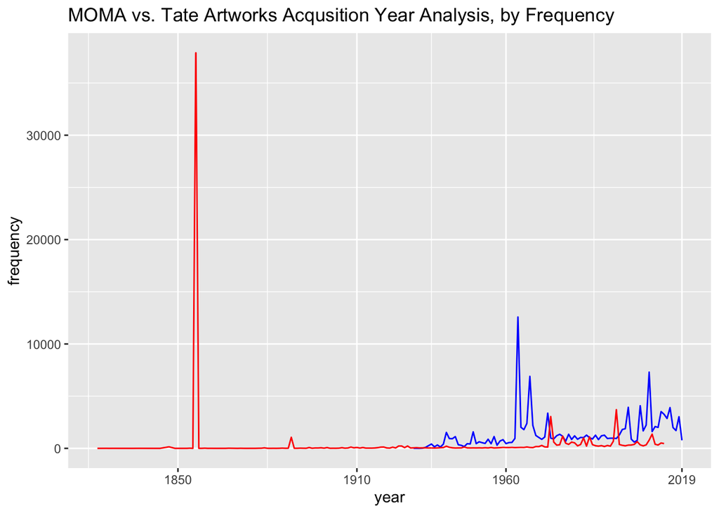

```r
  #scale_x_continuous(breaks = c(1925, 1950, 1975, 2000, 2021))

# plot
ggplot(data = test, aes(x = acq_yr, y = Total)) +
  geom_line(color = "blue") +
  ggtitle("MOMA vs. Tate Artworks Acqusition Year Analysis, by Frequency") +
  labs (x = "year", y = "frequency") +
  geom_line(data = tate_test, aes(x= acq_yr, y = Freq), color = "red") +
  scale_x_continuous(breaks = c(1850, 1910, 1960, 2019))
```

As we can see it hard to compare them as they have different starting years for artworks acquisition. Thus, we only focus on the year periods where they can be compared.

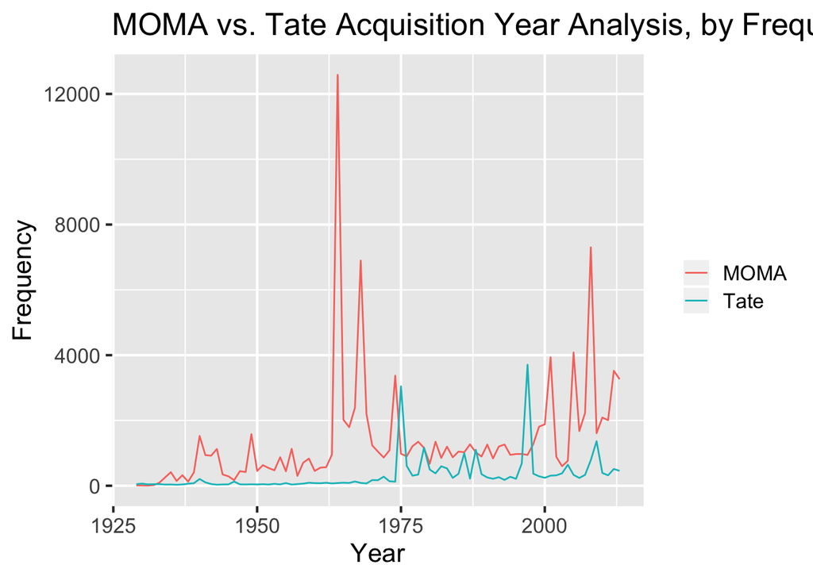

```r
# join on moma year
acq_yr_join <- merge(test, tate_test)
colnames(acq_yr_join)[2] <- "MOMA"
colnames(acq_yr_join)[3] <- "Tate"
tidy_df <- acq_yr_join %>% gather (key = "Museum", value = "Frequency", -acq_yr)

# plot joint df
ggplot(tidy_df, aes(acq_yr, Frequency, color = Museum)) +
  geom_line() +
  ggtitle("MOMA vs. Tate Acquisition Year Analysis, by Frequency") +
  theme_grey(16) +
  theme(legend.title = element_blank()) +
  labs(x = "Year", y = "Frequency")
```

```r
# what nationality in those years being collected? will they be in common or very different?

# first, lets see if we can tell who they are

# get moma artist name, year, acq year
moma_artist_yr <- moma_real[c(1,7)] %>% mutate(acq_yr = substr(DateAcquired, 1,4))
moma_artist_yr$acq_yr <- strtoi(moma_artist_yr$acq_yr)
moma_artist_yr <- moma_artist_yr %>% group_by(acq_yr) %>% filter(acq_yr >= 1970 & acq_yr <= 1980)
moma_artist_yr <- moma_artist_yr %>% group_by(acq_yr, Artist) %>% dplyr::summarize(Total = n()) %>% arrange(Total)
# sum(moma_artist_yr$Total) = 13877
# Ludwig Mies van der Rohe has 772, which is 5.6% by himself of the stuff collected by MOMA

tate_real_yr <- tate_real %>% group_by(acquisitionYear) %>% filter(acquisitionYear >= 1970 & acquisitionYear <= 1980)
tate_real_yr <- tate_real_yr %>% group_by(acquisitionYear, artist) %>% dplyr::summarise(Total = n()) %>% arrange(Total)

# sum(tate_real_yr$Total) = 6853
# Daniell, William has 612, which is 8.93%

# create new df
df_comp <- c(sum(moma_artist_yr$Total), sum(tate_real_yr$Total))

# frequency of nationality
# ggplot(df_comp, aes(fct_reorder(x, Frequency), Frequency)) +
#   geom_bar(stat = "identity") +
#   ggtitle("MOMA Artist Nationality by Frequency (top 5%)") +
#   xlab("Nationality") +
#   geom_col(color = mycolor, fill = myfill) +
#   coord_flip() +
#   theme(plot.title = element_text(face = "bold"))
```

```r
# if just narrow down to 1973-1976
moma_artist_yr3 <- moma_real[c(1,7)] %>% mutate(acq_yr = substr(DateAcquired, 1,4))
moma_artist_yr3$acq_yr <- strtoi(moma_artist_yr3$acq_yr)
moma_artist_yr3 <- moma_artist_yr3 %>% group_by(acq_yr) %>% filter(acq_yr >= 1973 & acq_yr <= 1976)
moma_artist_yr3 <- moma_artist_yr3 %>% group_by(acq_yr, Artist) %>% dplyr::summarize(Total = n()) %>% arrange(Total)

tate_real_yr3 <- tate_real %>% group_by(acquisitionYear) %>% filter(acquisitionYear >= 1973 & acquisitionYear <= 1976)
tate_real_yr3 <- tate_real_yr3 %>% group_by(acquisitionYear, artist) %>% dplyr::summarise(Total = n()) %>% arrange(Total)

# 6338 (moma) vs. 3916 (tate)
```

```r
tate_med <- tate_artwork[c(8,11)]
tate_med <- tate_med %>% group_by(acquisitionYear, medium) %>% dplyr::summarize(Total = n()) %>% arrange(Total)

# get medium from year 1973 - 1976
tate_med_yr <- tate_med %>% group_by(acquisitionYear) %>% filter(acquisitionYear >= 1973 & acquisitionYear <= 1976)

quantile(tate_med_yr$Total, c(.99))
```

```
##    99%
## 230.44
```

```r
# top 1% is above 230.44; thus, essentially, we take the top 5 and plot
```

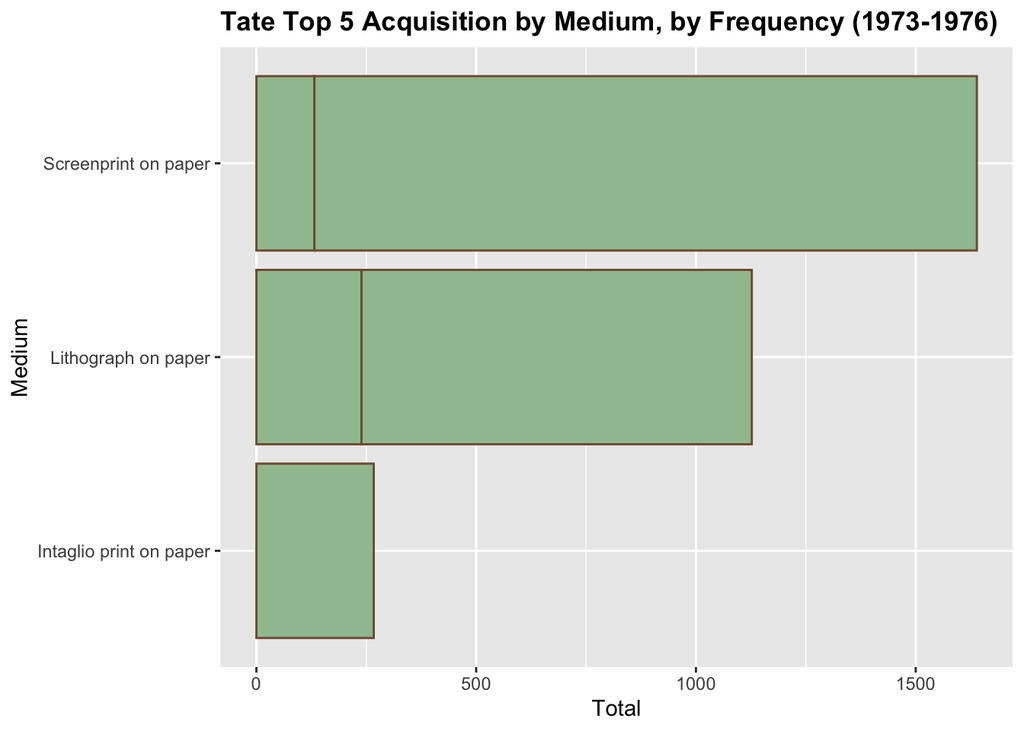

```r
tate_med_yr_top5 <- tate_med_yr %>% group_by(Total) %>% filter(Total > 100)
# frequency of nationality

ggplot(tate_med_yr_top5, aes(medium, Total)) +
  geom_bar(stat = "identity") +
  ggtitle("Tate Top 5 Acquisition by Medium, by Frequency (1973-1976)") +
  xlab("Medium") +
  geom_col(color = mycolor, fill = myfill) +
  coord_flip() +
  theme(plot.title = element_text(face = "bold"))
```

```r
# check donation on Ludwig Mies van der Rohe

moma_lud <- moma_real[c(1,5,7)] %>% mutate(acq_yr = substr(DateAcquired, 1,4))
moma_lud <- moma_lud %>% group_by(Artist) %>% filter(Artist == 'Ludwig Mies van der Rohe')
moma_lud <- moma_lud %>% group_by(acq_yr) %>% filter (acq_yr >= 1973 & acq_yr <= 1976)
moma_lud <- moma_lud %>% group_by(acq_yr, Medium) %>% dplyr::summarize(Total = n()) %>% arrange(Total)

# 542 are pencil on paper
```